# MarketingAnalytics_Lab3

### 1. Load Libraries

```python
import numpy as np
import pandas as pd
import matplotlib.pyplot as plt
import seaborn as sns

from sklearn.model_selection import train_test_split
from sklearn.ensemble import RandomForestClassifier
from sklearn.tree import DecisionTreeClassifier
from sklearn.metrics import accuracy_score, precision_score, recall_score
from sklearn.metrics import confusion_matrix

import warnings
warnings.filterwarnings('ignore')
```

### 2. Load Data

```python
df_raw = pd.read_csv('Customer_Behavior_Data.csv', delimiter=';', decimal=',')
df_raw.head()
```

|  | account length | location code | user id | credit card info save | push status | add to wishlist | desktop sessions | app sessions | desktop transactions | total product detail views | session duration | promotion clicks | avg order value | sale product views | discount rate per visited products | product detail view per app session | app transactions | add to cart per session | customer service calls | churn |
| --- | --- | --- | --- | --- | --- | --- | --- | --- | --- | --- | --- | --- | --- | --- | --- | --- | --- | --- | --- | --- |
| 0 | 128 | 415 | 3824657 | no | yes | 25 | 265 | 45 | 17 | 110 | 197 | 87 | 244.7 | 91 | 11.01 | 10.0 | 3 | 2.70 | 1 | 0 |
| 1 | 107 | 415 | 3717191 | no | yes | 26 | 162 | 27 | 17 | 123 | 196 | 103 | 254.4 | 103 | 11.45 | 13.7 | 3 | 3.70 | 1 | 0 |
| 2 | 137 | 415 | 3581921 | no | no | 0 | 243 | 41 | 10 | 114 | 121 | 110 | 162.6 | 104 | 7.32 | 12.2 | 5 | 3.29 | 0 | 0 |
| 3 | 84 | 408 | 3759999 | yes | no | 0 | 299 | 51 | 5 | 71 | 62 | 88 | 196.9 | 89 | 8.86 | 6.6 | 7 | 1.78 | 2 | 0 |
| 4 | 75 | 415 | 3306626 | yes | no | 0 | 167 | 28 | 13 | 113 | 148 | 122 | 186.9 | 121 | 8.41 | 10.1 | 3 | 2.73 | 3 | 0 |

```python
# df_raw.to_csv('Formatted_Customer_Behavior_Data.csv')
```

# EDA

With every new dataset we need to got throuhg an EDA (Exploratory Data Analysis) process. It's a good idea to have a basic framework in mind for our EDAs. It is always a good idea to:

- Understand what our columns say
- Rename columns labels and make them lowercase
- Make sure that the data types of columns are correct
- Handle missing values
- Check for duplicates
- Search for outliers
- Check for linearity between variables

To achieve this we can take advantage of Pandas and visualisation libraries

# Statistical Analysis

Are there missing values in the data? (see .info() results) so we can move on and check our descriptive statistics with the .describe() function.

```python
# Rename the columns with an underscore to read them without effort
df = df_raw.copy()

df.columns = df.columns.str.replace(' ', '_')
df.columns
```

```
Index(['account_length', 'location_code', 'user_id', 'credit_card_info_save',
       'push_status', 'add_to_wishlist', 'desktop_sessions', 'app_sessions',
       'desktop_transactions', 'total_product_detail_views',
       'session_duration', 'promotion_clicks', 'avg_order_value',
       'sale_product_views', 'discount_rate_per_visited_products',
       'product_detail_view_per_app_session', 'app_transactions',
       'add_to_cart_per_session', 'customer_service_calls', 'churn'],
      dtype='object')
```

```python
# Check the datatypes of the columns
df.head()
```

|  | account_length | location_code | user_id | credit_card_info_save | push_status | add_to_wishlist | desktop_sessions | app_sessions | desktop_transactions | total_product_detail_views | session_duration | promotion_clicks | avg_order_value | sale_product_views | discount_rate_per_visited_products | product_detail_view_per_app_session | app_transactions | add_to_cart_per_session | customer_service_calls | churn |
| --- | --- | --- | --- | --- | --- | --- | --- | --- | --- | --- | --- | --- | --- | --- | --- | --- | --- | --- | --- | --- |
| 0 | 128 | 415 | 3824657 | no | yes | 25 | 265 | 45 | 17 | 110 | 197 | 87 | 244.7 | 91 | 11.01 | 10.0 | 3 | 2.70 | 1 | 0 |
| 1 | 107 | 415 | 3717191 | no | yes | 26 | 162 | 27 | 17 | 123 | 196 | 103 | 254.4 | 103 | 11.45 | 13.7 | 3 | 3.70 | 1 | 0 |
| 2 | 137 | 415 | 3581921 | no | no | 0 | 243 | 41 | 10 | 114 | 121 | 110 | 162.6 | 104 | 7.32 | 12.2 | 5 | 3.29 | 0 | 0 |
| 3 | 84 | 408 | 3759999 | yes | no | 0 | 299 | 51 | 5 | 71 | 62 | 88 | 196.9 | 89 | 8.86 | 6.6 | 7 | 1.78 | 2 | 0 |
| 4 | 75 | 415 | 3306626 | yes | no | 0 | 167 | 28 | 13 | 113 | 148 | 122 | 186.9 | 121 | 8.41 | 10.1 | 3 | 2.73 | 3 | 0 |

```python
# Check for potential outliers
df.describe()
```

|  | account_length | location_code | user_id | add_to_wishlist | desktop_sessions | app_sessions | desktop_transactions | total_product_detail_views | session_duration | promotion_clicks | avg_order_value | sale_product_views | discount_rate_per_visited_products | product_detail_view_per_app_session | app_transactions | add_to_cart_per_session | customer_service_calls | churn |
| --- | --- | --- | --- | --- | --- | --- | --- | --- | --- | --- | --- | --- | --- | --- | --- | --- | --- | --- |
| count | 3333.000000 | 3333.000000 | 3.333000e+03 | 3333.000000 | 3333.000000 | 3333.000000 | 3333.000000 | 3333.000000 | 3333.000000 | 3333.000000 | 3333.000000 | 3333.000000 | 3333.000000 | 3333.000000 | 3333.000000 | 3333.000000 | 3333.000000 | 3333.000000 |
| mean | 101.064806 | 437.182418 | 3.746291e+06 | 8.099010 | 179.811881 | 30.567957 | 17.087609 | 100.435644 | 201.039604 | 100.110711 | 200.872037 | 100.107711 | 9.039325 | 10.237294 | 4.479448 | 2.764581 | 1.562856 | 0.144914 |
| std | 39.822106 | 42.371290 | 2.746626e+05 | 13.688365 | 54.457135 | 9.269376 | 4.323795 | 20.069084 | 50.714359 | 19.923911 | 50.573847 | 19.568609 | 2.275873 | 2.791840 | 2.461214 | 0.753773 | 1.315491 | 0.352067 |
| min | 1.000000 | 408.000000 | 3.271058e+06 | 0.000000 | 0.000000 | 0.000000 | 0.000000 | 0.000000 | 0.000000 | 0.000000 | 23.200000 | 33.000000 | 1.040000 | 0.000000 | 0.000000 | 0.000000 | 0.000000 | 0.000000 |
| 25% | 74.000000 | 408.000000 | 3.508680e+06 | 0.000000 | 144.000000 | 24.000000 | 14.000000 | 87.000000 | 167.000000 | 87.000000 | 167.000000 | 87.000000 | 7.520000 | 8.500000 | 3.000000 | 2.300000 | 1.000000 | 0.000000 |
| 50% | 101.000000 | 415.000000 | 3.748187e+06 | 0.000000 | 179.000000 | 31.000000 | 17.000000 | 101.000000 | 201.000000 | 100.000000 | 201.200000 | 100.000000 | 9.050000 | 10.300000 | 4.000000 | 2.780000 | 1.000000 | 0.000000 |
| 75% | 127.000000 | 510.000000 | 3.985970e+06 | 20.000000 | 216.000000 | 37.000000 | 20.000000 | 114.000000 | 235.000000 | 114.000000 | 235.300000 | 113.000000 | 10.590000 | 12.100000 | 6.000000 | 3.270000 | 2.000000 | 0.000000 |
| max | 243.000000 | 510.000000 | 4.229964e+06 | 51.000000 | 351.000000 | 60.000000 | 31.000000 | 165.000000 | 364.000000 | 170.000000 | 395.000000 | 175.000000 | 17.770000 | 20.000000 | 20.000000 | 5.400000 | 9.000000 | 1.000000 |

### 3. Handle missing values

Missing values can be an issue with most real-life datasets. We can use the .info() function, there are no missing values. For the sake of double checking and to show a way of checking whether the dataset has missing values, let's write some code below

```python
# Check for datatypes in the data
df.user_id = df.user_id.astype('str')
df.location_code = df.location_code.astype('str')
df.info()
```

```
<class 'pandas.core.frame.DataFrame'>
RangeIndex: 3333 entries, 0 to 3332
Data columns (total 20 columns):
 #   Column                               Non-Null Count  Dtype
---  ------                               --------------  -----
 0   account_length                       3333 non-null   int64
 1   location_code                        3333 non-null   object
 2   user_id                              3333 non-null   object
 3   credit_card_info_save                3333 non-null   object
 4   push_status                          3333 non-null   object
 5   add_to_wishlist                      3333 non-null   int64
 6   desktop_sessions                     3333 non-null   int64
 7   app_sessions                         3333 non-null   int64
 8   desktop_transactions                 3333 non-null   int64
 9   total_product_detail_views           3333 non-null   int64
 10  session_duration                     3333 non-null   int64
 11  promotion_clicks                     3333 non-null   int64
 12  avg_order_value                      3333 non-null   float64
 13  sale_product_views                   3333 non-null   int64
 14  discount_rate_per_visited_products   3333 non-null   float64
 15  product_detail_view_per_app_session  3333 non-null   float64
 16  app_transactions                     3333 non-null   int64
 17  add_to_cart_per_session              3333 non-null   float64
 18  customer_service_calls               3333 non-null   int64
 19  churn                                3333 non-null   int64
dtypes: float64(4), int64(12), object(4)
memory usage: 520.9+ KB
```

```python
# Check for missing values in the data
df.isnull().sum()
```

```
account_length                         0
location_code                          0
user_id                                0
credit_card_info_save                  0
push_status                            0
add_to_wishlist                        0
desktop_sessions                       0
app_sessions                           0
desktop_transactions                   0
total_product_detail_views             0
session_duration                       0
promotion_clicks                       0
avg_order_value                        0
sale_product_views                     0
discount_rate_per_visited_products     0
product_detail_view_per_app_session    0
app_transactions                       0
add_to_cart_per_session                0
customer_service_calls                 0
churn                                  0
dtype: int64
```

### 4. Check and handle duplicates

Another common issue with data is duplicated records. We need to make sure to always check for duplicates

```python
# Making sure that the dataset doesnt contain duplicate records

df.user_id.nunique()
```

```
3333
```

The dataset contains 3333 records each with unique user_id data which confirms that there are no duplicates in the dataset

### 5. Find and handle outliers

- Outliers are data points at the extreme points of a dataset
- Some outliers represent true values from natural variation in the population and some occur because of dirty or incorrect data.
  - Because of this, we need to be careful when we cleanse our data
  - If the outliers are True outliers, we should probably keep them in our data since they represent natural variations in our sample.
  - If the outliers are errors, we should generally remove those data points.

We've already identified some potential outliers from our .describe() functions with session durations, average order value, promotion clicks, sale product views, app transactions, account length, add to wish list, desktop sessions, and customer service calls.

To identify our outliers, we can use:

- Visualizations such as histograms and box plots Use interquartiles with rules such as:
  - outlier < Q1 - 1.5 x IQR
  - outlier > Q3 + 1.5 x IQR

### 6. Visualize all the variables

This is EDA, so we are going to visualize all the variables we identified as having potentail outliers

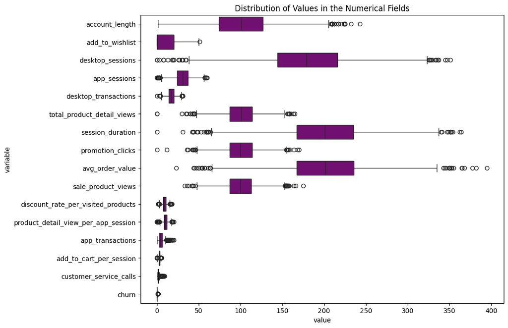

```python
# Visualize the variables having potential outliers

num_cols = df.select_dtypes('number').columns

plt.figure(figsize=(10, 8))
sns.boxplot(data = df.melt(value_vars= num_cols), y='variable', x='value', color='purple')
plt.title('Distribution of Values in the Numerical Fields')
plt.show()
```

```python
# Visualizations are done using Tableau
```

### 7. Conclusions based on visualizations

- All of the numerical variables in the dataset has outliers from a statistical point of view. What is apparent is that all of the outliers represent natural variations as in e-commerce we expect such variations, making the outliers "True outliers".
- If we had Outliers that we believe them to be data errors we could always use techniques such as removing all data points that are < Q1 - 1.5(IQR) and > Q3 +1.5(IQR) or removing data points that are 3 standard deviations below or above mean (example code below if you need to use it)

```python
# Clean the outliers using IQR

# def remove_outliers(df, col):
#     q1 = df[col].quantile(0.25)
#     q3 = df[col].quantile(0.75)
#     iqr = q3 - q1
#     lower_lim = q1 - 1.5 * iqr
#     upper_lim = q3 + 1.5 * iqr
#     df = df[(df[col] >= lower_lim) & (df[col] <= upper_lim)]
#     return df


def remove_outliers_list(df, col_list):
    for col in col_list:
        q1 = df[col].quantile(0.25)
        q3 = df[col].quantile(0.75)
        iqr = q3 - q1
        lower_lim = q1 - 1.5 * iqr
        upper_lim = q3 + 1.5 * iqr
        df = df[(df[col] >= lower_lim) & (df[col] <= upper_lim)]
    return df
```

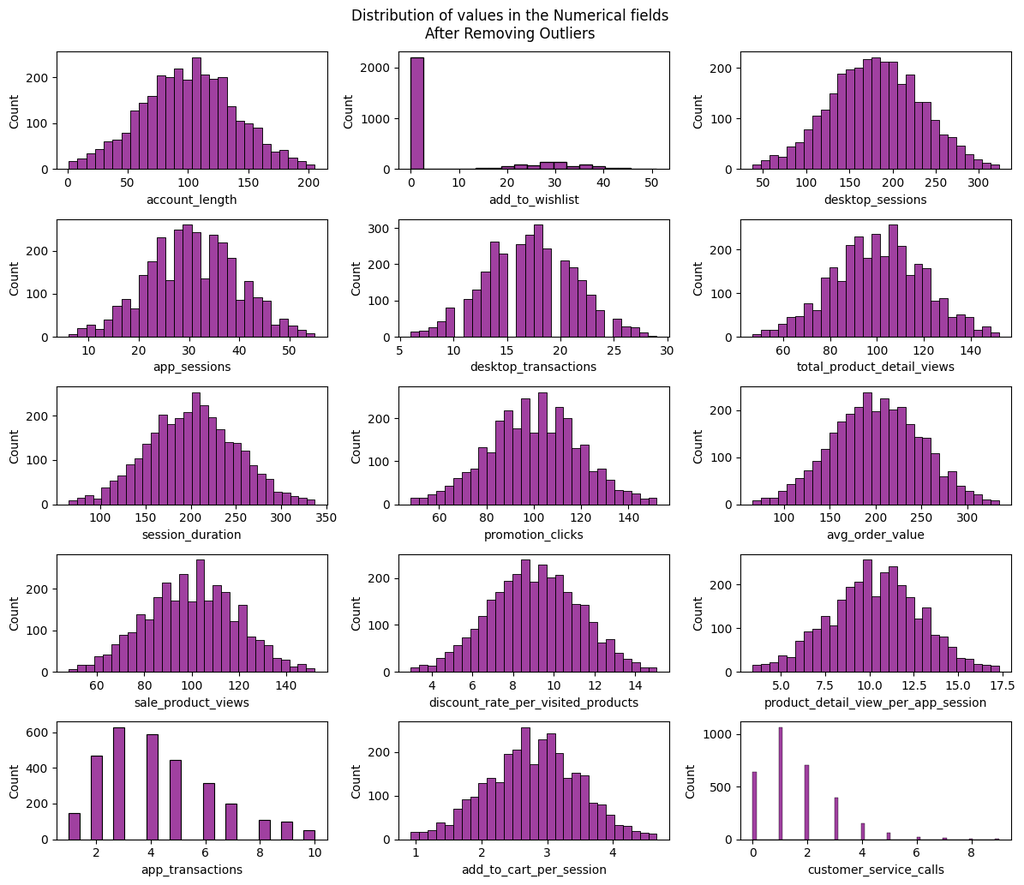

```python
col_list = ['account_length', 'avg_order_value', 'desktop_sessions', 'total_product_detail_views', 'sale_product_views',
            'app_transactions', 'promotion_clicks', 'product_detail_view_per_app_session', 'add_to_cart_per_session',
            'session_duration']

df_cleaned = remove_outliers_list(df, col_list)

plt.figure(figsize=(12, 30))
count = 1

for i in num_cols[:-1]:
    plt.subplot(15, 3, count)
    sns.histplot(df_cleaned[i], color='purple')
    count += 1
plt.suptitle('Distribution of values in the Numerical fields\nAfter Removing Outliers\n\n')
plt.tight_layout()
plt.show()
```

```python
df_cleaned.shape
```

```
(3046, 20)
```

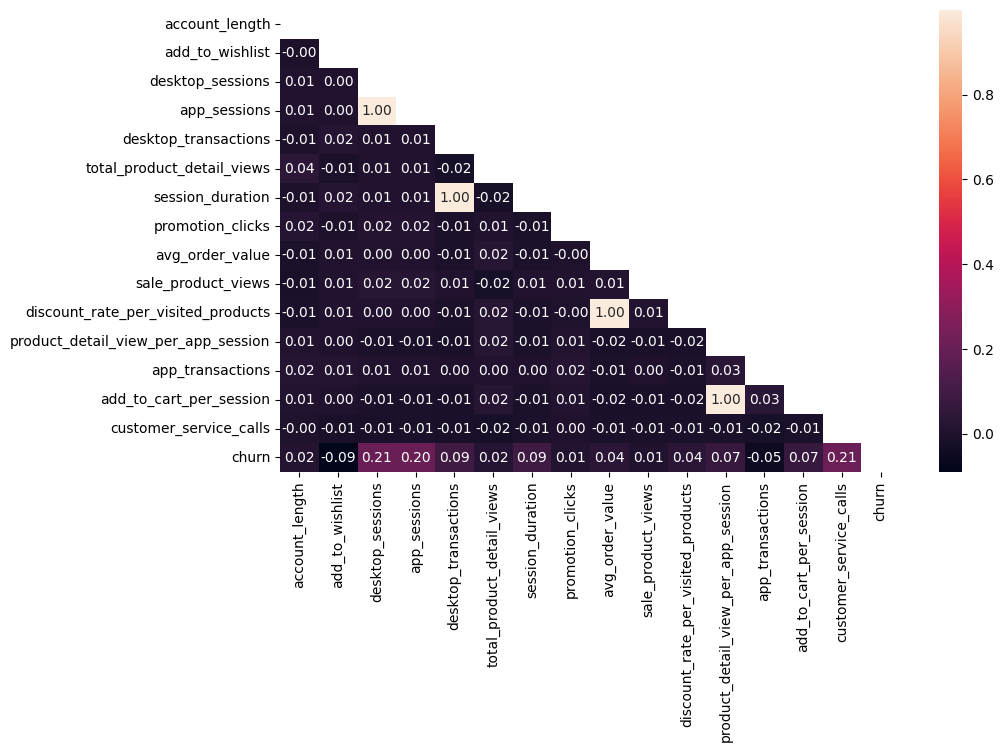

```python
# Check for Correlation and Colinearity among the variables

corr = df[num_cols].corr()
matrix = np.triu(corr)

plt.figure(figsize=(10, 6))
sns.heatmap(corr, annot=True, mask=matrix, fmt=".2f")
plt.show()
```

```python
# Check linearity between variables
linear_cols = ['desktop_sessions', 'app_sessions',
               'desktop_transactions', 'session_duration',
               'avg_order_value', 'discount_rate_per_visited_products',
               'product_detail_view_per_app_session', 'add_to_cart_per_session']
df[linear_cols].head()
```

|  | desktop_sessions | app_sessions | desktop_transactions | session_duration | avg_order_value | discount_rate_per_visited_products | product_detail_view_per_app_session | add_to_cart_per_session |
| --- | --- | --- | --- | --- | --- | --- | --- | --- |
| 0 | 265 | 45 | 17 | 197 | 244.7 | 11.01 | 10.0 | 2.70 |
| 1 | 162 | 27 | 17 | 196 | 254.4 | 11.45 | 13.7 | 3.70 |
| 2 | 243 | 41 | 10 | 121 | 162.6 | 7.32 | 12.2 | 3.29 |
| 3 | 299 | 51 | 5 | 62 | 196.9 | 8.86 | 6.6 | 1.78 |
| 4 | 167 | 28 | 13 | 148 | 186.9 | 8.41 | 10.1 | 2.73 |

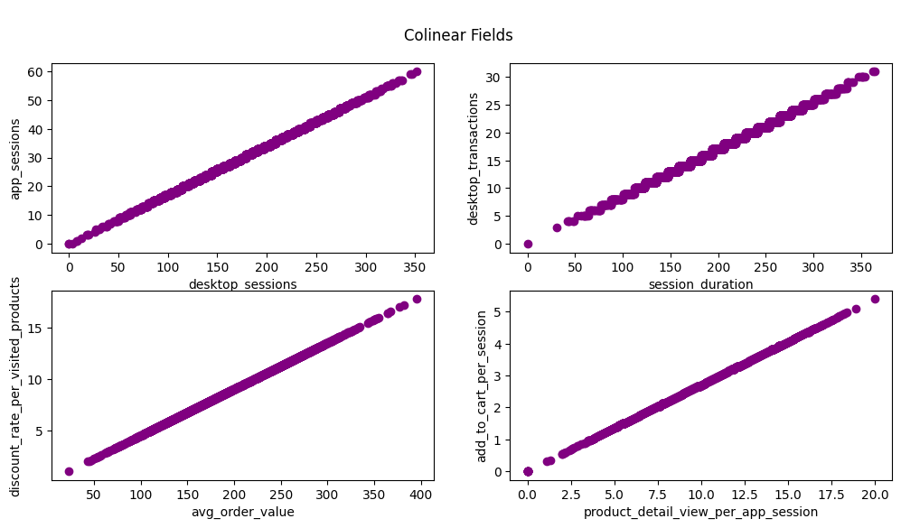

```python
# Plot the colinear fields to show the relationship

pri_fields = ['desktop_sessions', 'session_duration', 'avg_order_value', 'product_detail_view_per_app_session']
sec_fields = ['app_sessions', 'desktop_transactions', 'discount_rate_per_visited_products', 'add_to_cart_per_session']

row_num = col_num = 0
color = 'purple'

fig, axes = plt.subplots(nrows=2, ncols=2, figsize = (12, 6))
for pri, sec in zip(pri_fields, sec_fields):
    axes[row_num][col_num].scatter(df[pri], df[sec], color=color)
    axes[row_num][col_num].set_xlabel(pri)
    axes[row_num][col_num].set_ylabel(sec)
    if col_num == 0:
        col_num += 1
    else:
        row_num += 1
        col_num -= 1

fig.suptitle('\nColinear Fields')
plt.show()
```

### 8. Analysis of 'Churn' vs other Features

Until now we've looked into the numeric variables, their missing data, duplicates, distribution, and outliers. A key part of the customer behaviour data is to understand which "behaviours" aka idependent varialbes in our dataset can help us predict customers deciding to stop using the product, aka "churn".

Another variable that we haven't analysed yet is the location code, but we might be able to find value in comparing it with the churn and finding out any potential correlations.

```python
# Visualizations are done using Tableau
```

### 9. Plot Churn against categorical data

#### 9.1 Observations from categorical columns plots

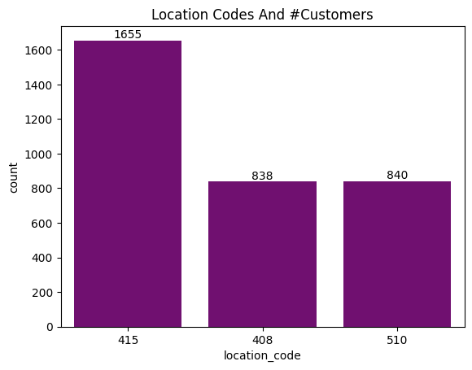

```python
ax = sns.countplot(x=df['location_code'], color=color)
ax.bar_label(ax.containers[0])
plt.title('Location Codes And #Customers')
plt.show()
```

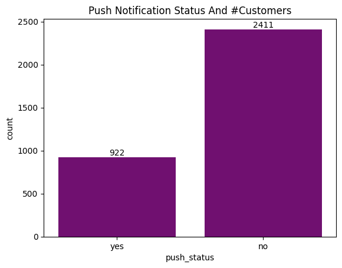

```python
ax = sns.countplot(x=df['push_status'], color=color)
ax.bar_label(ax.containers[0])
plt.title('Push Notification Status And #Customers')
plt.show()
```

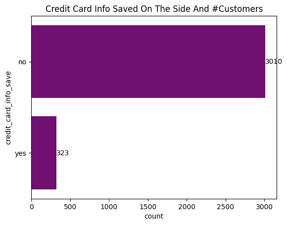

```python
ax = sns.countplot(y=df['credit_card_info_save'], color=color)
ax.bar_label(ax.containers[0])
plt.title('Credit Card Info Saved On The Side And #Customers')
plt.show()
```

#### 9.2 Plot categorical data against the Churn

```python
# Visualisations are done using Tableau
```

#### 9.4 Observations from plotting categorical data against Churn

```python
# Visualizations are done using Tableau
```

# 10. Data Preprocessing

```python
df.head()
```

|  | account_length | location_code | user_id | credit_card_info_save | push_status | add_to_wishlist | desktop_sessions | app_sessions | desktop_transactions | total_product_detail_views | session_duration | promotion_clicks | avg_order_value | sale_product_views | discount_rate_per_visited_products | product_detail_view_per_app_session | app_transactions | add_to_cart_per_session | customer_service_calls | churn |
| --- | --- | --- | --- | --- | --- | --- | --- | --- | --- | --- | --- | --- | --- | --- | --- | --- | --- | --- | --- | --- |
| 0 | 128 | 415 | 3824657 | no | yes | 25 | 265 | 45 | 17 | 110 | 197 | 87 | 244.7 | 91 | 11.01 | 10.0 | 3 | 2.70 | 1 | 0 |
| 1 | 107 | 415 | 3717191 | no | yes | 26 | 162 | 27 | 17 | 123 | 196 | 103 | 254.4 | 103 | 11.45 | 13.7 | 3 | 3.70 | 1 | 0 |
| 2 | 137 | 415 | 3581921 | no | no | 0 | 243 | 41 | 10 | 114 | 121 | 110 | 162.6 | 104 | 7.32 | 12.2 | 5 | 3.29 | 0 | 0 |
| 3 | 84 | 408 | 3759999 | yes | no | 0 | 299 | 51 | 5 | 71 | 62 | 88 | 196.9 | 89 | 8.86 | 6.6 | 7 | 1.78 | 2 | 0 |
| 4 | 75 | 415 | 3306626 | yes | no | 0 | 167 | 28 | 13 | 113 | 148 | 122 | 186.9 | 121 | 8.41 | 10.1 | 3 | 2.73 | 3 | 0 |

```python
# Drop primary key: user_id
df_model = df.drop(columns='user_id')
df_model.head()
```

|  | account_length | location_code | credit_card_info_save | push_status | add_to_wishlist | desktop_sessions | app_sessions | desktop_transactions | total_product_detail_views | session_duration | promotion_clicks | avg_order_value | sale_product_views | discount_rate_per_visited_products | product_detail_view_per_app_session | app_transactions | add_to_cart_per_session | customer_service_calls | churn |
| --- | --- | --- | --- | --- | --- | --- | --- | --- | --- | --- | --- | --- | --- | --- | --- | --- | --- | --- | --- |
| 0 | 128 | 415 | no | yes | 25 | 265 | 45 | 17 | 110 | 197 | 87 | 244.7 | 91 | 11.01 | 10.0 | 3 | 2.70 | 1 | 0 |
| 1 | 107 | 415 | no | yes | 26 | 162 | 27 | 17 | 123 | 196 | 103 | 254.4 | 103 | 11.45 | 13.7 | 3 | 3.70 | 1 | 0 |
| 2 | 137 | 415 | no | no | 0 | 243 | 41 | 10 | 114 | 121 | 110 | 162.6 | 104 | 7.32 | 12.2 | 5 | 3.29 | 0 | 0 |
| 3 | 84 | 408 | yes | no | 0 | 299 | 51 | 5 | 71 | 62 | 88 | 196.9 | 89 | 8.86 | 6.6 | 7 | 1.78 | 2 | 0 |
| 4 | 75 | 415 | yes | no | 0 | 167 | 28 | 13 | 113 | 148 | 122 | 186.9 | 121 | 8.41 | 10.1 | 3 | 2.73 | 3 | 0 |

```python
df_model.info()
```

```
<class 'pandas.core.frame.DataFrame'>
RangeIndex: 3333 entries, 0 to 3332
Data columns (total 19 columns):
 #   Column                               Non-Null Count  Dtype
---  ------                               --------------  -----
 0   account_length                       3333 non-null   int64
 1   location_code                        3333 non-null   object
 2   credit_card_info_save                3333 non-null   object
 3   push_status                          3333 non-null   object
 4   add_to_wishlist                      3333 non-null   int64
 5   desktop_sessions                     3333 non-null   int64
 6   app_sessions                         3333 non-null   int64
 7   desktop_transactions                 3333 non-null   int64
 8   total_product_detail_views           3333 non-null   int64
 9   session_duration                     3333 non-null   int64
 10  promotion_clicks                     3333 non-null   int64
 11  avg_order_value                      3333 non-null   float64
 12  sale_product_views                   3333 non-null   int64
 13  discount_rate_per_visited_products   3333 non-null   float64
 14  product_detail_view_per_app_session  3333 non-null   float64
 15  app_transactions                     3333 non-null   int64
 16  add_to_cart_per_session              3333 non-null   float64
 17  customer_service_calls               3333 non-null   int64
 18  churn                                3333 non-null   int64
dtypes: float64(4), int64(12), object(3)
memory usage: 494.9+ KB
```

```python
# Handle Categorical fields
cat_cols = df_model.select_dtypes('object').columns

for col in cat_cols:
    print(df_model[col].value_counts(), '\n')
```

```
location_code
415    1655
510     840
408     838
Name: count, dtype: int64

credit_card_info_save
no     3010
yes     323
Name: count, dtype: int64

push_status
no     2411
yes     922
Name: count, dtype: int64
```

```python
df_model['location_code'].replace({'408': 1, '415': 2, '510': 3}, inplace=True)
df_model['credit_card_info_save'].replace({'yes': 1, 'no': 0}, inplace=True)
df_model['push_status'].replace({'yes': 1, 'no': 0}, inplace=True)

df_model[cat_cols].value_counts()
```

```
location_code  credit_card_info_save  push_status
2              0                      0              1082
1              0                      0               567
3              0                      0               531
2              0                      1               423
3              0                      1               207
1              0                      1               200
2              1                      0               102
3              1                      0                78
1              1                      0                51
2              1                      1                48
3              1                      1                24
1              1                      1                20
Name: count, dtype: int64
```

```python
df_model.head()
```

|  | account_length | location_code | credit_card_info_save | push_status | add_to_wishlist | desktop_sessions | app_sessions | desktop_transactions | total_product_detail_views | session_duration | promotion_clicks | avg_order_value | sale_product_views | discount_rate_per_visited_products | product_detail_view_per_app_session | app_transactions | add_to_cart_per_session | customer_service_calls | churn |
| --- | --- | --- | --- | --- | --- | --- | --- | --- | --- | --- | --- | --- | --- | --- | --- | --- | --- | --- | --- |
| 0 | 128 | 2 | 0 | 1 | 25 | 265 | 45 | 17 | 110 | 197 | 87 | 244.7 | 91 | 11.01 | 10.0 | 3 | 2.70 | 1 | 0 |
| 1 | 107 | 2 | 0 | 1 | 26 | 162 | 27 | 17 | 123 | 196 | 103 | 254.4 | 103 | 11.45 | 13.7 | 3 | 3.70 | 1 | 0 |
| 2 | 137 | 2 | 0 | 0 | 0 | 243 | 41 | 10 | 114 | 121 | 110 | 162.6 | 104 | 7.32 | 12.2 | 5 | 3.29 | 0 | 0 |
| 3 | 84 | 1 | 1 | 0 | 0 | 299 | 51 | 5 | 71 | 62 | 88 | 196.9 | 89 | 8.86 | 6.6 | 7 | 1.78 | 2 | 0 |
| 4 | 75 | 2 | 1 | 0 | 0 | 167 | 28 | 13 | 113 | 148 | 122 | 186.9 | 121 | 8.41 | 10.1 | 3 | 2.73 | 3 | 0 |

# 11. Model Building

```python
# Data preparation
X = df_model.drop(columns='churn')
y = df_model['churn']

# Train test split
X_train, X_test, y_train, y_test = train_test_split(X, y, train_size=0.8)
```

#### Decision Tree Model

```python
tree_classifier = DecisionTreeClassifier()
tree_classifier.fit(X_train,y_train)
score= tree_classifier.score(X_test,y_test)
print(score)
```

```
0.8950524737631185
```

```python
y_pred = tree_classifier.predict(X_test)

tree_acc     = accuracy_score(y_pred, y_test)
tree_prec    = precision_score(y_pred, y_test)
tree_recall  = recall_score(y_pred, y_test)
```

```python
# Display the metrics on the predicted values.

print(f'Accuracy score:  {tree_acc: .2%}')
print(f'Precision score: {tree_prec: .2%}')
print(f'Recall score:    {tree_recall: .2%}')
```

```
Accuracy score:   89.51%
Precision score:  63.27%
Recall score:     64.58%
```

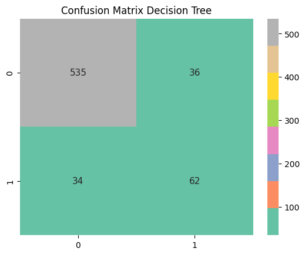

```python
cm_tree = confusion_matrix(y_pred, y_test)

sns.heatmap(cm_tree, annot=True, fmt='g',  cmap='Set2', annot_kws={"fontsize":11})
plt.title('Confusion Matrix Decision Tree')
plt.show()
```

### Random Forest Classifier Model

```python
trees = [125, 150, 175, 200, 225, 250, 275, 300, 325, 350, 375, 400]
accs = []
precs = []
recalls = []
f1scores = []

for ntrees in trees:
    classifier = RandomForestClassifier(n_estimators=ntrees)
    classifier.fit(X_train, y_train)
    y_preds = classifier.predict(X_test)

    acc     = accuracy_score(y_preds, y_test)
    prec    = precision_score(y_preds, y_test)
    recall  = recall_score(y_preds, y_test)
    f1s     = f1_score(y_preds, y_test)

    accs.append(round(acc, 2))
    precs.append(round(prec, 2))
    recalls.append(round(recall, 2))
    f1scores.append(round(f1s, 2))
```

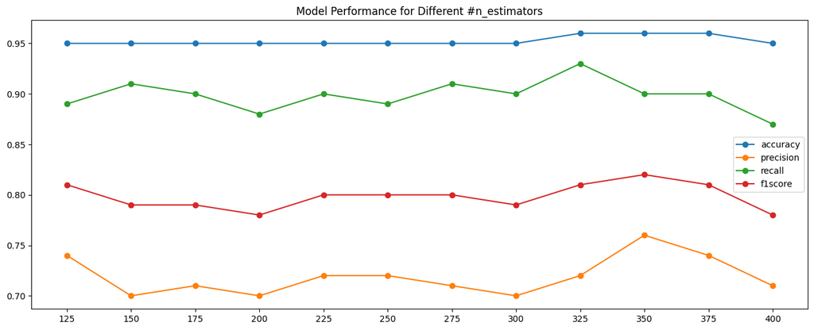

```python
plt.figure(figsize=(16, 6))
metrics = [accs, precs, recalls, f1scores]

for metric in metrics:
    plt.plot(trees, metric, marker='o')

plt.xticks(trees)
plt.legend(['accuracy', 'precision', 'recall', 'f1score'])
plt.title('Model Performance for Different #n_estimators')
plt.show()
```

```python
# Build and train model
classifier = RandomForestClassifier(n_estimators=325)
classifier.fit(X_train, y_train)
```

```
RandomForestClassifier(n_estimators=325)
```

```python
# Check the model performance on test set
accuracy = classifier.score(X_test, y_test)
print(f'Model Performance on Test data:{accuracy: .2%}')
```

```
Model Performance on Test data: 94.75%
```

```python
# Get predictions for the test data
y_preds = classifier.predict(X_test)

acc     = accuracy_score(y_preds, y_test)
prec    = precision_score(y_preds, y_test)
recall  = recall_score(y_preds, y_test)
```

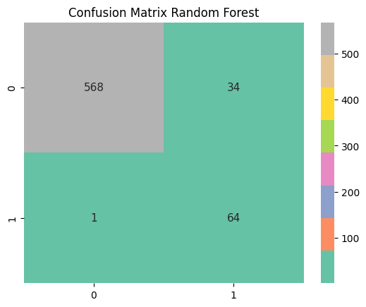

```python
cm = confusion_matrix(y_preds, y_test)

sns.heatmap(cm, annot=True, fmt='g',  cmap='Set2', annot_kws={"fontsize":11})
plt.title('Confusion Matrix Random Forest')
plt.show()
```

```python
# Display the metrics on the predicted values.

print(f'Accuracy score:  {acc: .2%}')
print(f'Precision score: {prec: .2%}')
print(f'Recall score:    {recall: .2%}')
```

```
Accuracy score:   94.75%
Precision score:  65.31%
Recall score:     98.46%
```

##### In this scenario, as we need to accurately predict the customers who would churn, Recall is the ideal metric to evaluate the score of the model to identify the actual churn rate.